# Styles and Climate Analysis (Proof-of-concept)

KFI research

Note: This POC is to showcase the type of text analysis that we could do to support our studies. I generally relied on this framework here (https://www.tidytextmining.com/) for the analysis

Before I dive into the modelling aspect of the analysis, I did some exploratory analysis. These are the names of the variables.

```
## [1] "GroupID"    "PerID"      "UserName"   "Version"    "Assessor"
## [6] "Strengths"  "Weaknesses" "language"
```

Here is the distribution of **‘Version’** variable (in %). **JR’s comments: Any idea what’s the meaning of this variable?**

```
##
##    1    2    3    4    5
## 14.5  0.0 85.5  0.0  0.0
```

And the distribution of **‘Assessor’** variable (in %). **JR’s comments: Any idea what’s the meaning of this variable?**

```
##
##    1    2    3    4    5    6    7    8    9   10   11   12   13   14   15
## 27.9 13.3 12.3 10.1  8.2  6.0  4.6  3.5  2.8  2.2  1.6  1.3  1.0  0.8  0.7
##   16   17   18   19   20   21   22   23   24   25   26   27   28   29   30
##  0.5  0.4  0.4  0.3  0.3  0.2  0.2  0.1  0.1  0.1  0.1  0.1  0.1  0.1  0.1
##   31   32   33   34   35   36   37   38   39   40   41   42   43   44   45
##  0.1  0.0  0.0  0.0  0.0  0.0  0.0  0.0  0.0  0.0  0.0  0.0  0.0  0.0  0.0
##   46   47   48   49   50   51   52   53   54   55   56   57   58   59   60
##  0.0  0.0  0.0  0.0  0.0  0.0  0.0  0.0  0.0  0.0  0.0  0.0  0.0  0.0  0.0
##   61   62   63   64   65   66   67   68   69   70   71   72   73   74   75
##  0.0  0.0  0.0  0.0  0.0  0.0  0.0  0.0  0.0  0.0  0.0  0.0  0.0  0.0  0.0
##   76   77   78   79   80   81   82   83   84   85   86   87   88   89   90
##  0.0  0.0  0.0  0.0  0.0  0.0  0.0  0.0  0.0  0.0  0.0  0.0  0.0  0.0  0.0
##   91   92   93   94   95   96   97   98   99  100  101  102  103  104  105
##  0.0  0.0  0.0  0.0  0.0  0.0  0.0  0.0  0.0  0.0  0.0  0.0  0.0  0.0  0.0
##  107  108  110  111  112  116  117  119  120  121  122  124  126  134  138
##  0.0  0.0  0.0  0.0  0.0  0.0  0.0  0.0  0.0  0.0  0.0  0.0  0.0  0.0  0.0
##  144  146  149  153  159  165  169  171  173  176  178  183  184  187  188
##  0.0  0.0  0.0  0.0  0.0  0.0  0.0  0.0  0.0  0.0  0.0  0.0  0.0  0.0  0.0
##  189  194  197  199  208  214  223  236  244  245  246  261  264  267  270
##  0.0  0.0  0.0  0.0  0.0  0.0  0.0  0.0  0.0  0.0  0.0  0.0  0.0  0.0  0.0
##  274  284  289  291  294  297  301  302  306  309  313  317  318  320  326
##  0.0  0.0  0.0  0.0  0.0  0.0  0.0  0.0  0.0  0.0  0.0  0.0  0.0  0.0  0.0
##  337  338  339  345  347
##  0.0  0.0  0.0  0.0  0.0
```

From observation, the data consists of a mixture of languages. Hence, I assigned a language tag to each data point via R’s textcat Natural Language Processing package. Here is a distribution (in %) of the languages over 306,127 data points.

```
##
##           afrikaans            albanian              basque
##                 0.1                 0.0                 0.2
##             bosnian              breton             catalan
##                 0.0                 0.1                 0.9
##      croatian-ascii     czech-iso8859_2              danish
##                 0.0                 0.5                 0.4
##               dutch             english           esperanto
##                 4.7                41.8                 0.1
##            estonian             finnish              french
##                 0.0                 0.3                 1.5
##             frisian              german     greek-iso8859-7
##                 0.1                 3.4                 0.0
##    hebrew-iso8859_8           hungarian           icelandic
##                 0.0                 0.0                 0.0
##          indonesian               irish             italian
##                 0.2                 0.0                 4.1
##               latin             latvian          lithuanian
##                 0.2                 0.0                 0.0
##               malay                manx      middle_frisian
##                 0.3                 0.0                 0.3
##              nepali           norwegian              polish
##                 1.2                 0.2                 4.3
##          portuguese            romanian           rumantsch
##                 4.7                 0.6                 0.2
##   russian-iso8859_5 russian-windows1251            sanskrit
##                 0.4                 0.0                 0.1
##               scots        scots_gaelic       serbian-ascii
##                 0.5                21.1                 0.0
##        slovak-ascii  slovak-windows1250     slovenian-ascii
##                 0.3                 0.5                 0.0
## slovenian-iso8859_2             spanish             swahili
##                 0.5                 4.9                 0.1
##             swedish             tagalog             turkish
##                 0.2                 0.1                 0.6
##    ukrainian-koi8_r               welsh
##                 0.0                 0.1
```

Then I limit my analysis to only the data points tagged with ‘English Language’. Future developments could involve using Google Translate API to convert the Non-English text to English. But I’m not inclined to do since there’re usually subtle nuances associated with each language.

Here is an example of the 1st 2 rows in the dataset (only Strengths used here. I left out ‘Weaknesses’ column in the analysis).

[output not shown]

Then I tokenize the dataset through unigrams i.e 1 word / term

Next I identify stop words in the data frame by merging in a taxonomy from tidytext package. And removed them thereafter.

Count function is used to find the most common words under the ‘Strengths Column’.

```
## # A tibble: 1,818,657 x 3
## # Groups:   PerID, word [1,818,657]
##              PerID    word     n
##              <chr>   <chr> <int>
##  1 PERW00003836809   blake    69
##  2 PERW00003966489   bruce    58
##  3 PERW00000682009    jodi    54
##  4 PERW00003294783   chris    54
##  5 PERW00003426714  dennis    53
##  6 PERW00002254570    alex    50
##  7 PERW00003221887    ryan    50
##  8 PERW00003294783   staff    47
##  9 PERW00003888470 college    47
## 10 PERW00003936643  mahesh    45
## # ... with 1,818,647 more rows
```

[figure not shown]

## Sentiment analysis

1 of the common toolkits in text analysis is Sentiment Analysis. Using an existing sentiment taxonomy, I’m able to tag words as positive or negative.

```
## # A tibble: 351,312 x 4
##              PerID     word sentiment     n
##              <chr>    <chr>     <chr> <int>
##  1 PERW00003981424     dawn  positive    24
##  2 PERW00003845007 felicity  positive    23
##  3 PERW00003423518     rich  positive    22
##  4 PERW00001762977 felicity  positive    19
##  5 PERW00002745670     dawn  positive    18
##  6 PERW00000340577     rich  positive    17
##  7 PERW00003121524     hung  negative    17
##  8 PERW00003175058      sue  negative    16
##  9 PERW00002591517     rich  positive    14
## 10 PERW00002737543     dawn  positive    14
## # ... with 351,302 more rows
```

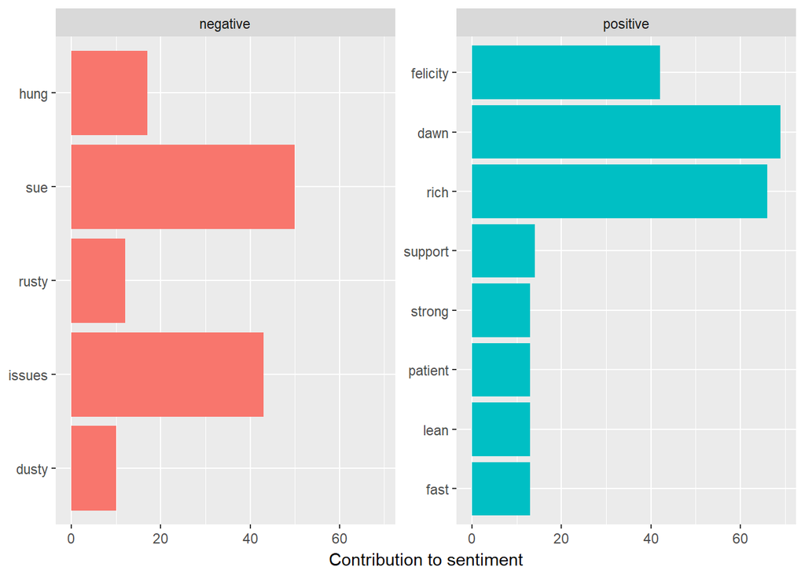

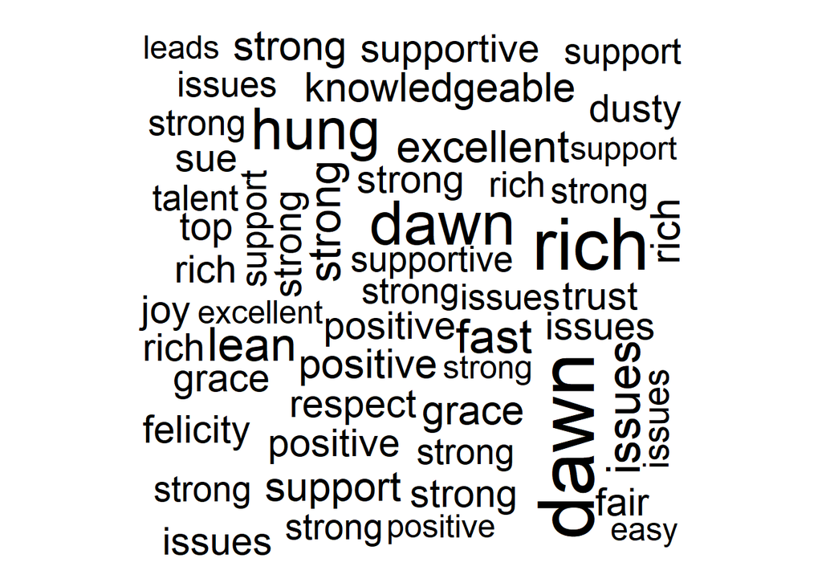

## TF-IDF (KIV this section first)

## Topic-Modelling

Next, I fit a document term matrix into the Latent Dirichlet Allocation (LDA) unsupervised machine-learning framework. ‘Unsupervised Machine Learning’ is just a fancy way of saying Exploratory Thematic Analysis.

As a POC, I set 2 as the number of latent topics that are able to represent the dataset. There are diagnostics to determine the optimal number which I will use in future iterations.

```
## A LDA_VEM topic model with 2 topics.
```

## Word-topic probabilities

LDA allows us to extract per-topic-per-word probabilities (Beta) from the model.

The model assigned probabilities to each term of being generated from either of the 2 topics.

As you notice, many of the terms below are not formatted properly (e.g. remove non-alphabets; keep only the root words through stemming). I will do so in further iterations.

```
## # A tibble: 110,862 x 3
##    topic        term         beta
##    <int>       <chr>        <dbl>
##  1     1       focus 0.0026359311
##  2     2       focus 0.0013706535
##  3     1    business 0.0154700483
##  4     2    business 0.0065423658
##  5     1       takes 0.0029217964
##  6     2       takes 0.0027582734
##  7     1        care 0.0008927590
##  8     2        care 0.0008688091
##  9     1 environment 0.0022719225
## 10     2 environment 0.0019375043
## # ... with 110,852 more rows
```

Model could be further tuned to obtain better distinctions (e.g. increasing number of topics, further data-cleaning, using n-grams i.e. n words per term instead of 1 word per term now)

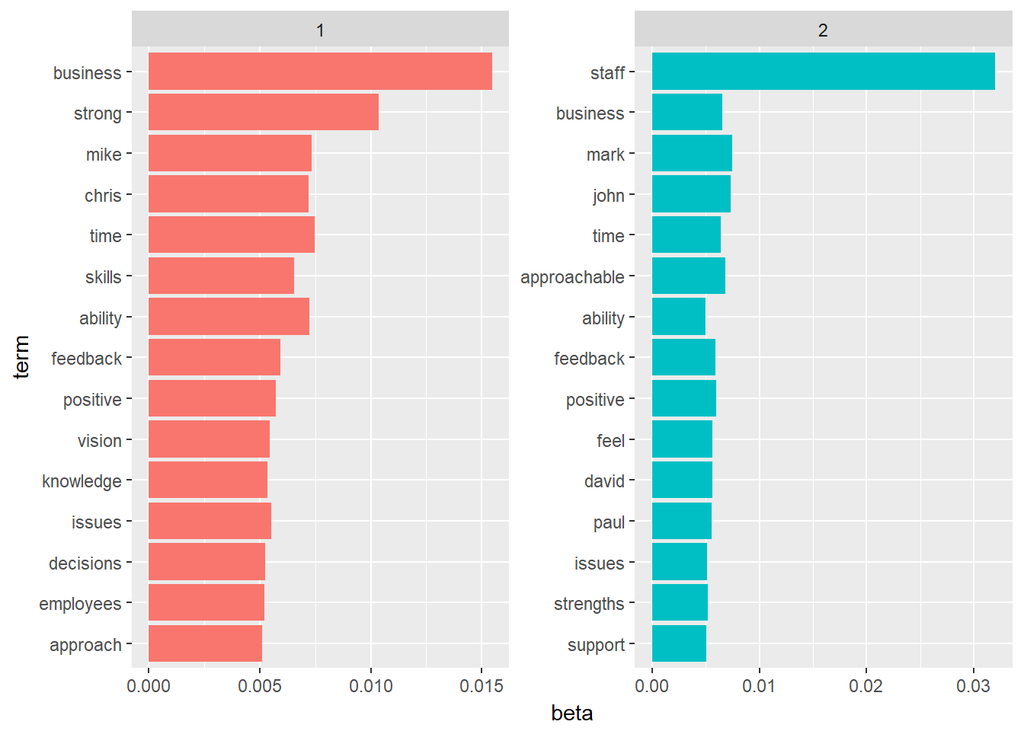

## Per-document classification

```
## # A tibble: 51,084 x 3
##           document topic        gamma
##              <chr> <int>        <dbl>
##  1 PERB00000075249     1 9.999012e-01
##  2 PERB00000075249     2 9.875317e-05
##  3 PERB00000075585     1 2.719577e-04
##  4 PERB00000075585     2 9.997280e-01
##  5 PERB00000075620     1 9.993708e-01
##  6 PERB00000075620     2 6.292172e-04
##  7 PERB00000102742     1 9.998531e-01
##  8 PERB00000102742     2 1.468708e-04
##  9 PERB00000102895     1 1.560967e-01
## 10 PERB00000102895     2 8.439033e-01
## # ... with 51,074 more rows
```

### Potential applications

With LDA, we’re able to find out the topics that are commonly associated with high performers. And if there’re demographic and job variables, we can explore these tendencies by gender, occupations, industries, etc.